# Estrellas en el manto de Nuestra Señora de Guadalupe

Juan M. Fonseca-Solís · julio 2025 - setiembre 2026

## Resumen

En este ipython notebook estudiamos el problema planteado por varios investigadores de determinar si las cuarenta y seis estrellas del manto celeste de Nuestra Señora de Guadalupe son constelaciones reales y si corresponden con aquellas visibles en el cielo de la Ciudad de México al momento de la impregnación. Este es un problema interesante de abordar, no solo por su dimensión catequética, sino también porque permite aplicar teoría de topología, astronomía, así como conceptos de probabilidad y estadística. En 2022, el Instituto de Estudios Guadalupanos de Mérida (ISEG) determinó que existe una correlación del 91,08% para la constelación Osa Mayor, visible en aquel momento. Aunque no logramos replicar el resultado exacto, logramos acercarnos empleando un método alternativo que usa el plugin "control-remoto" de Stellarium y la distancia euclidiana en una imagen rasterizada.

## Motivación

### Armonía iconográfica y musical

Para comprender por qué se ha planteado que el manto de Nuestra Señora de Guadalupe contiene constelaciones reales y no puntos colocados al azar, es necesario mencionar otras similitudes con el mundo real. Primero, la posición de las flores en forma de códice de su manto café concuerdan en un 92,13% con la posición de los principales cerros y volcanes de la orografía de México. Segundo, las dimensiones de su imagen presentan una geometría áurea, obtenida al dividir 1,7 m por 1,05 m. Tercero, las flores y estrellas de la imagen son verticalmente equidistantes entre sí y, al sobreponer un pentagrama sobre ellas, es posible componer una armonía musical [15, 16]. Y cuarto, la elipse formada por el sol a sus espaldas tiene un centro, y es geométrico, y corresponde con dos elementos: la posición en el vientre de María donde se encuentra Jesús, y la flor de cuatro pétalos, o *Nahui Ollin* (Dios siempre en movimiento, según los indígenas mexicanos) [25].1

[figure not shown]

Figura 1. Nuestra Señora de Guadalupe. Fotografía del cuadro obsequiado por el Pbro. Andrés Hernández a la parroquia de San Josecito.

## El estudio de Ojeda

En 2022, David y Daniel Ojeda determinaron que la posición de las 46 estrellas del manto de Nuestra Señora de Guadalupe corresponde, en un 97,75%, a la posición de doce de las constelaciones visibles en el cielo de la Ciudad de México al momento aproximado de la impregnación (12 de diciembre de 1531 a las 6:45 am). El método empleado es el siguiente.2

1. Con los parámetros indicados en la tabla 1, obtuvieron un planisferio visible en el cielo de la Ciudad de México.

Tabla 1. Parámetros usados por Ojeda et al.

| Parámetro | Valor |
| --- | --- |
| Latitud | 19 grados, 25 minutos y 40 segundos |
| Longitud | 99 horas, 7 minutos y 4 segundos |
| Fecha | 12 de diciembre de 1531 (calendario gregoriano) |
| Hora | 6:45 a.m. (horario de invierno) |

2. Del planisferio, extrayeron las coordenadas ecuatoriales de las estrellas visibles en el cielo, es decir, aquellas con magnitud aparente menor o igual a 6 unidades. Las coordenadas ecuatoriales se expresan en términos de ascensión recta o longitud, denotada por $\lambda$ , y declinación o latitud, denotada por $\varphi$.3
3. Aplicaron la transformada de Mercator a las coordenadas ecuatoriales de las estrellas en las constelaciones para pasarlas de un espacio tridimensional a otro bidimensional, que permitiera su comparación con la tilma.
4. Empezando por la Cruz del Sur, usaron la proyección de Mercator para averiguar visualmente cuales constelaciones estaban contenidas en el manto azul-verde de la Virgen, y dónde exactamente.
5. Para las constelaciones identificadas en ambos lados, calcularon las distancias entre los pares de estrellas adyacentes. En el caso de la tilma, midieron la distancia en milímetros con una regla; y en el caso del planisferio, emplearon la distancia ortodrómica o geodésica, como se muestra abajo [27]4: $$ d = 111{,}23\cos^{-1}\big[\sin(\varphi_1) \sin(\varphi_2) + \cos(\varphi_1) \cos(\varphi_2) \cos(\lambda_1-\lambda_2)\big]\quad [1]. $$ En la ecuación, 111,23 km es la distancia que cubre un grado al igualar el radio de la esfera celeste con el terrestre.5
6. Manteniendo el mismo orden en los pares adyacentes, construyeron dos vectores distintos, $\vec{x}, \vec{y}$, con las distancias obtenidas y aplicaron el método de [correlación de Pearson](https://es.wikipedia.org/wiki/Coeficiente_de_correlaci%C3%B3n_de_Pearson) sobre ellos para obtener una medida de similitud [2]:

$$ \rho_{\vec{x}, \vec{y}} = \frac{\text{cov}(\vec{x}, \vec{y})}{\sqrt{\text{var}(\vec{x})\text{var}(\vec{y})}} $$

La tabla 2 muestra los resultados reportados por estos autores para la constelación Ursa Majoris (Ojeda et. al, minuto 44:46 del video) [2].

Tabla 2. Distancias entre estrellas de la constelación Osa Mayor calculadas por Ojeda et al.

| Estrellas Osa Mayor | Tilma (mm) | Planisferio (km) |
| --- | --- | --- |
| HR-5191 a HR-5054 | 650 | 744.16 |
| HR-5054 a HR-4905 | 550 | 484.98 |
| HR-4905 a HR-4660 | 650 | 604.01 |
| HR-4660 a HR-4554 | 650 | 503.89 |
| HR-4554 a HR-4295 | 700 | 878.76 |
| HR-4295 a HR-4301 | 600 | 598.44 |
| HR-4301 a HR-4660 | 800 | 1134.60 |
| HR-4301 a HR-3757 | 950 | 1193.55 |
| HR-3757 a HR-3323 | 800 | 837.60 |
| HR-3757 a HR-3888 | 600 | 518.35 |
| **Correlación** | - | 91.08% |

## Resultados obtenidos

En las siguientes secciones, replicamos los cálculos realizados por Ojeda y Ojeda sobre la constelación Osa Mayor, pero esta vez automatizando el proceso de extracción de datos con el plugin "control-remoto" de Stellarium [30].

### Planisferio de Stellarium

Usando Stellarium, consultamos las coordenadas de las estrellas con los parámetros de la tabla 1. Para efectos de visualización y verificación (sin que esto afecte los cálculos siguientes), dibujamos los puntos en un espacio 3D mediante la ecuación 2. Con ella convertimos la ascención recta, $\lambda$, y declinación, $\varphi$, a coordenadas cartesianas.

$$\langle{x, y, z}\rangle = \left\langle{\sin\left(\lambda\right),\,\cos(\lambda),\,\sin(\varphi)}\right\rangle \quad [2].$$

```
[Alkaid/HR-5191/85 Ursae Majoris] AR (en fecha): -157.77 (-157h -46m -14.0s), DEC (en fecha): 51.68 (51° 40m 59.2s), mag: 1.86.
[Mizar/HR-5054/79 Ursae Majoris] AR (en fecha): -163.80 (-163h -48m -9.4s), DEC (en fecha): 57.40 (57° 23m 44.3s), mag: 2.22.
[Alioth/HR-4905/77 Ursae Majoris] AR (en fecha): -171.75 (-171h -44m -56.8s), DEC (en fecha): 58.52 (58° 30m 59.9s), mag: 1.77.
[Megrez/HR-4660/69 Ursae Majoris] AR (en fecha): 177.90 (177h 54m 11.0s), DEC (en fecha): 59.63 (59° 37m 59.1s), mag: 3.32.
[Phecda/HR-4554/64 Ursae Majoris] AR (en fecha): 172.14 (172h 8m 12.8s), DEC (en fecha): 56.29 (56° 17m 10.6s), mag: 2.44.
[Merak/HR-4295/48 Ursae Majoris] AR (en fecha): 158.17 (158h 10m 9.4s), DEC (en fecha): 58.85 (58° 50m 57.7s), mag: 2.37.
[Dubhe/HR-4301/50 Ursae Majoris] AR (en fecha): 158.42 (158h 24m 54.3s), DEC (en fecha): 64.23 (64° 13m 55.0s), mag: 1.79.
[23 UMa/HR-3757/23 Ursae Majoris] AR (en fecha): 133.29 (133h 17m 28.1s), DEC (en fecha): 64.99 (64° 59m 35.6s), mag: 3.67.
[ο UMa/HR-3323/01 Ursae Majoris] AR (en fecha): 117.59 (117h 35m 8.9s), DEC (en fecha): 62.13 (62° 7m 56.9s), mag: 3.42.
[υ UMa/HR-3888/29 Ursae Majoris] AR (en fecha): 139.14 (139h 8m 16.5s), DEC (en fecha): 61.15 (61° 8m 54.5s), mag: 3.81.
```

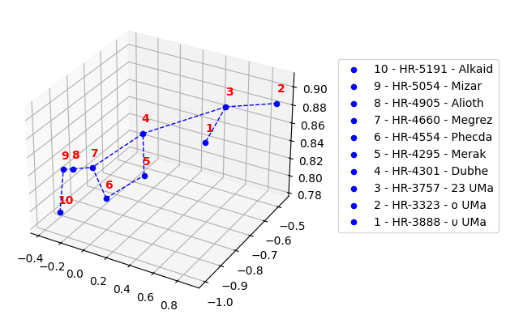

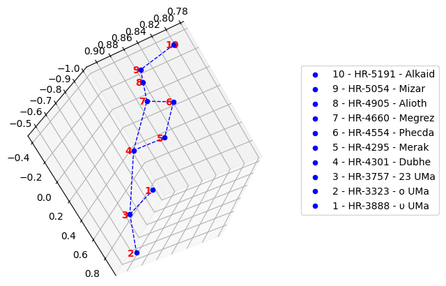

```python
import sys
sys.path.append('./src')
from constellation_factory import ConstellationFactory
import pprint
import numpy as np
import matplotlib.pylab as plt

if __name__ == '__main__':
    constellation_factory = ConstellationFactory(time=2280600.9895833335,
        latitude=19.427778244018555, longitude=-99.1177749633789, altitude=0)
    constellation = constellation_factory.get_constellation('osa_mayor')
    constellation.print()
    constellation.plot()
    constellation.plot([-28, 107, 113])
```

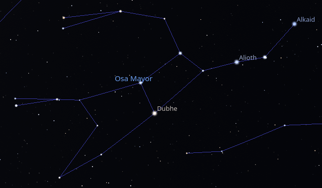

Figura 2. Osa Mayor, calculada (arriba) y de referencia (abajo, Stellarium).

Podemos observar que las gráficas construidas se asemejan al pantallazo realizado en Stellarium (figura 2). Este es un primer indicador que las coordenadas obtenidas son correctas.

### Distancia entre las estrellas del planisferio

Seguidamente, usamos la ecuación 1 para determinar la distancia en el plano celeste entre los pares de estrellas.

```python
from collections import OrderedDict
from star import Star

constellation_pairs = constellation.get_pairs([
        ['HR-5191', 'HR-5054'],
        ['HR-5054', 'HR-4905'],
        ['HR-4905', 'HR-4660'],
        ['HR-4660', 'HR-4554'],
        ['HR-4554', 'HR-4295'],
        ['HR-4295', 'HR-4301'],
        ['HR-4301', 'HR-4660'],
        ['HR-4301', 'HR-3757'],
        ['HR-3757', 'HR-3323'],
        ['HR-3757', 'HR-3888']
    ])

def calculate_orthodromic_distances_between_stair_pairs(constellation_pairs:list[list[Star]]) -> OrderedDict:
    km_per_degree = 111.23
    dict_distances_calc = OrderedDict()    # para preservar el orden de inserción empleamos un diccionario especial, en vez de {}
    for [star1, star2] in constellation_pairs:
        distance_rad = np.arccos(np.sin(star1.dec_rad) * np.sin(star2.dec_rad) + np.cos(star1.dec_rad) * np.cos(star2.dec_rad) * np.cos(star1.ar_rad-star2.ar_rad))
        distance_km = distance_rad * 180.0/np.pi * km_per_degree
        dict_distances_calc[(star1.hr_name, star2.hr_name)] = float(np.round(distance_km, 2))
    return dict_distances_calc

# obtenemos las distancias entre estrellas
dict_distances_planisphere_this_study = calculate_orthodromic_distances_between_stair_pairs(constellation_pairs)
distances_planisphere_this_study = np.array(list(dict_distances_planisphere_this_study.values()))
pprint.pprint(dict_distances_planisphere_this_study)
```

```
OrderedDict([(('HR-5191', 'HR-5054'), 744.51),
             (('HR-5054', 'HR-4905'), 484.93),
             (('HR-4905', 'HR-4660'), 603.74),
             (('HR-4660', 'HR-4554'), 503.99),
             (('HR-4554', 'HR-4295'), 878.68),
             (('HR-4295', 'HR-4301'), 598.85),
             (('HR-4301', 'HR-4660'), 1134.74),
             (('HR-4301', 'HR-3757'), 1193.16),
             (('HR-3757', 'HR-3323'), 837.53),
             (('HR-3757', 'HR-3888'), 518.81)])
```

Vemos que las distancias obtenidas son practicamente las mismas reportadas por Ojeda en la tabla 2, variando solo en sus decimales, y solamente en el par "HR-4905 a HR-4660" la variación es de una unidad. Este es un segundo indicador que las distancias obtenidas son correctas.

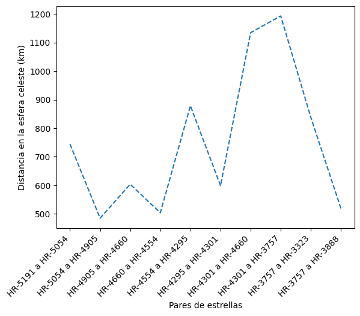

```python
pairs = [f'{x[0]} a {x[1]}' for x in dict_distances_planisphere_this_study.keys()]
plt.plot(pairs, distances_planisphere_this_study, '--')
plt.xticks(rotation=45, ha="right")
plt.xlabel('Pares de estrellas')
plt.ylabel('Distancia en la esfera celeste (km)')
```

### Distancia entre las estrellas del manto

A continuación, anotamos manualmente la posición de las estrellas de la Osa Mayor según los asterismo identificados por Ojeda et al. y, para cada par de estrellas, calculamos la distancia euclideana. La distancia no está en milímetros, sino en píxeles, sin embargo el método de Pearson debería ser invariante a la escala. Se usó una imagen distinta a la de la figura 1, ligeramente más oscurecida y donde se ven las estrellas con más claridad [26].

[figure not shown]

```
OrderedDict([(('HR-5191', 'HR-5054'), 52.27322450356396),
             (('HR-5054', 'HR-4905'), 46.999787233560966),
             (('HR-4905', 'HR-4660'), 63.056324028601644),
             (('HR-4660', 'HR-4554'), 49.083194680053154),
             (('HR-4554', 'HR-4295'), 49.93455717236311),
             (('HR-4295', 'HR-4301'), 42.710186138671865),
             (('HR-4301', 'HR-4660'), 50.89852650126524),
             (('HR-4301', 'HR-3757'), 78.3005108540168),
             (('HR-3757', 'HR-3323'), 62.30128409591567),
             (('HR-3757', 'HR-3888'), 43.745742649999656)])
```

```python
import matplotlib.image as plt_img
from constellation_doodle.coordinate_2d import Coordinate2D

HR_3323 = Coordinate2D('HR-3323', '01 Ursae Majoris', 'ο UMa', 177, 665)
HR_3757 = Coordinate2D('HR-3757', '23 Ursae Majoris', '23 UMa', 177.4, 602.7)
HR_4301 = Coordinate2D('HR-4301', '50 Ursae Majoris', 'Dubhe', 171.8, 524.6)
HR_3888 = Coordinate2D('HR-3888', '29 Ursae Majoris', 'υ UMa', 221.1, 604.7)
HR_4554 = Coordinate2D('HR-4554', '64 Ursae Majoris', 'Phecda', 237.9, 520.5)
HR_4660 = Coordinate2D('HR-4660', '69 Ursae Majoris', 'Megrez', 203.9, 485.1)
HR_4295 = Coordinate2D('HR-4295', '48 Ursae Majoris', 'Merak', 201.8, 555)
HR_5191 = Coordinate2D('HR-5191', '85 Ursae Majoris', 'Alkaid', 189.2, 332.9)
HR_5054 = Coordinate2D('HR-5054', '79 Ursae Majoris', 'Mizar', 168.5, 380.9)
HR_4905 = Coordinate2D('HR-4905', '77 Ursae Majoris', 'Alioth', 184.2, 425.2)

stars = [HR_3757, HR_3323, HR_4301, HR_3888, HR_4554, HR_4660, HR_4295, HR_5191, HR_5054, HR_4905]
asterism = [
    [HR_5191, HR_5054],
    [HR_5054, HR_4905],
    [HR_4905, HR_4660],
    [HR_4660, HR_4554],
    [HR_4554, HR_4295],
    [HR_4295, HR_4301],
    [HR_4301, HR_4660],
    [HR_4301, HR_3757],
    [HR_3757, HR_3323],
    [HR_3757, HR_3888]
]

# plot stars
plt.figure()
img_original = plt_img.imread('img/Virgen_de_guadalupe1.jpg')
plt.imshow(img_original)
for star in stars:
    plt.plot(star.x, star.y, 'x', color='white')
    plt.text(star.x+10.5, star.y-1.5, star.common_name, color='white')

# plot asterisms and calculate the euclidean distance between pairs of stars
dict_distances_tilma_this_study = OrderedDict()
for (star1, star2) in asterism:
    plt.plot([star1.x, star2.x], [star1.y, star2.y], color='white')
    dict_distances_tilma_this_study[(star1.hr_name, star2.hr_name)] = float(np.sqrt(np.power(star2.x-star1.x,2)+np.power(star2.y-star1.y,2)))

x_star = [star.x for star in stars]
y_star = [star.y for star in stars]
plt.xlim([min(x_star)*0.9, max(x_star)*1.3])
plt.ylim([max(y_star)*1.1, min(y_star)*0.9])
plt.show()
pprint.pprint(dict_distances_tilma_this_study)
distances_tilma_this_study = np.array(list(dict_distances_tilma_this_study.values()))
```

### Correlación visual entre las distancias

Para continuar, aplicamos una normalización de cada señal por su valor máximo. Esto con el fin de comparar visualmente las distancias de las estrellas en la esfera celeste (en kilómetros) con las de la tilma (en pixeles). La normalización nos permitió omitir las unidades de medida y dibujarlas en la misma grafica. Agregamos además las distancias de la tilma calculadas por Ojeda et al. (en mm).

En la figura observamos una correlación entre las distancias en pixeles y en milímetros, pues los picos y los valles calzan entre sí. Esto sucede en toda la señal excepto entre Megrez (HR-4660) y Phecda (HR-4554).

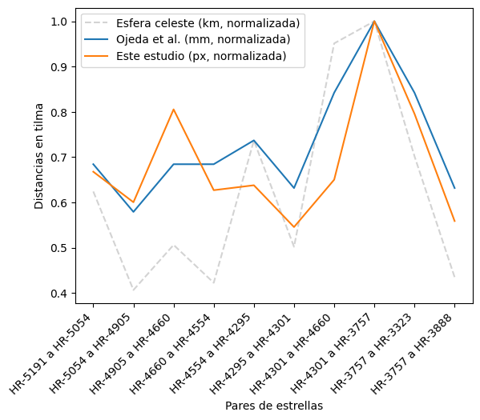

```python
distances_tilma_ojeda = np.array(list(OrderedDict([
    (('HR-5191', 'HR-5054'), 650.0),
    (('HR-5054', 'HR-4905'), 550.0),
    (('HR-4905', 'HR-4660'), 650.0),
    (('HR-4660', 'HR-4554'), 650.0),
    (('HR-4554', 'HR-4295'), 700.0),
    (('HR-4295', 'HR-4301'), 600.0),
    (('HR-4301', 'HR-4660'), 800.0),
    (('HR-4301', 'HR-3757'), 950.0),
    (('HR-3757', 'HR-3323'), 800.0),
    (('HR-3757', 'HR-3888'), 600.0)
]).values()))

plt.plot(pairs, distances_planisphere_this_study/max(distances_planisphere_this_study), '--', color='lightgray')
plt.plot(pairs, distances_tilma_ojeda/max(distances_tilma_ojeda))
plt.plot(pairs, distances_tilma_this_study/max(distances_tilma_this_study))
plt.xticks(rotation=45, ha="right")
plt.xlabel('Pares de estrellas')
plt.ylabel('Distancias en tilma')
plt.legend(['Esfera celeste (km, normalizada)', 'Ojeda et al. (mm, normalizada)', 'Este estudio (px, normalizada)'])
```

### Método de correlación de Pearson

Para terminar, calculamos la correlación de Pearson entre las distancias del planisferio y las distancias en la tilma. Los datos de Ojeda et al. nos permitieron obtener el mismo porcentaje publicado por ellos (con una desviación de tan solo dos centésimas) [2], pero al usar las distancias calculadas por nosotros (en pixeles sobre la tilma) obtuvimos un porcentaje menor. Lamentablemente, no tenemos el estudio completo de Ojeda et al. para determinar si el porcentaje incrementa usando la transformada de Mercator.6

```python
distances_planisphere_ojeda = np.array(list(OrderedDict([
    (('HR-5191', 'HR-5054'), 744.16),
    (('HR-5054', 'HR-4905'), 484.98),
    (('HR-4905', 'HR-4660'), 604.01),
    (('HR-4660', 'HR-4554'), 503.89),
    (('HR-4554', 'HR-4295'), 878.76),
    (('HR-4295', 'HR-4301'), 598.44),
    (('HR-4301', 'HR-4660'), 1134.6),
    (('HR-4301', 'HR-3757'), 1193.55),
    (('HR-3757', 'HR-3323'), 837.6),
    (('HR-3757', 'HR-3888'), 518.35)
]).values()))

def pearson_correlation(x:list[float], y:list[float]) -> float:
    return 100.0 * np.cov(x,y, bias=True)[0][1]/(np.std(x)*np.std(y)) # 'bias=True' para normalizar por 1/N

correlation_tilma_ojeda_planisphere_ojeda = pearson_correlation(distances_tilma_ojeda, distances_planisphere_ojeda)
correlation_tilma_ojeda_planisphere_this_study = pearson_correlation(distances_tilma_ojeda, distances_planisphere_this_study)
correlation_tilma_planisphere_this_study  = pearson_correlation(distances_tilma_this_study, distances_planisphere_this_study)

print(f'Correlaciones entre distancias\n---')
print(f'Tilma Ojeda / planisferio Ojeda: {correlation_tilma_ojeda_planisphere_ojeda:.2f}%')
print(f'Tilma Ojeda / planisferio este estudio: {correlation_tilma_ojeda_planisphere_this_study:.2f}%')
print(f'Tilma este estudio / planisferio este estudio: {correlation_tilma_planisphere_this_study:.2f}%')
```

```
Correlaciones entre distancias
---
Tilma Ojeda / planisferio Ojeda: 91.08%
Tilma Ojeda / planisferio este estudio: 91.06%
Tilma este estudio / planisferio este estudio: 61.56%
```

## Conclusiones

En este estudio mencionamos algunos patrones orográficos, astronómicos, geométricos y musicales de la naturaleza que se repiten en la imagen de Nuestra Señora de Guadalupe. Luego profundizamos la similitud astronómica presentada por Ojeda et al. y su método para calcular un porcentaje de correlación entre las estrellas del manto de la Virgen y las constelaciones visibles en el cielo al momento y lugar de la aparición. Finalmente, propusimos un método para tratar de replicar los resultados obtenidos por estos autores para la constelación Osa Mayor, automatizando el proceso con el plugin de control-remoto de Stellarium y aplicando la distancia euclideana. Aunque no obtuvimos el porcentaje de correlación exacto (por diferencias en las medidas en la tilma), sí logramos obtener las mismas distancias en la esfera celeste e identificamos una desviación solo entre Megrez (HR-4660) y Phecda (HR-4554) para las medidas en la tilma.

## Apéndice

Estudiar la imagen de Nuestra Señora de Guadalupe sin mencionar su aparición y códice nos privaría de apreciar su función más importante, que es anunciar el evangelio conciliando la visión judeo-europea e indígena-mexicana del mundo.

#### Visión judeo-europea

De acuerdo a Chávez citando a Sánchez, "ella es la mujer de Apocalipsis 12, 1-2" [1, 3]:

> "*1. Y apareció en el cielo un gran signo: una Mujer revestida del sol, con la luna bajo sus pies y una corona de doce estrellas en su cabeza.*"

> "*2. Estaba embarazada y gritaba de dolor porque iba a dar a luz.*"

Algunas de las observaciones brindadas son las siguientes [4, 5].

- San Juan Diego Cuauhtlatoatzin (del pueblo chichimeca), la presenta a Fray Juan de Zumarraga como la señal (o signo) solicitada para corroborar la autenticidad del mensaje transmitido [8, 11].
- Como dice la cita bíblica, su imagen indica que viene del cielo: está rodeada por rayos de sol y nubes, tiene la luna debajo de sus pies, y su manto está lleno de estrellas.
- Aunque la corona de estrellas no es visible en la imagen, los estudios de Ojeda et al. señalan que la constelación Corona Borealis está reflejada en el manto sobre su cabeza, en el mismo ángulo de inclinación de su rostro [2].
- De acuerdo con la costumbre indígena, es virgen, pues su cabello está suelto; y se encuentra embarazada, pues porta un lazo negro sobre su vientre [9].
- Su aparición del 9 al 12 de diciembre concuerda cronológicamente con el tiempo litúrgico de Adviento, momento en que la Iglesia Católica se prepara para celebrar el nacimiento de Nuestro Señor Jesucristo, y también con *Panquetzaliztli* (pascua indígena florida), momento cuando los nativos mexicanos realizaban sus sacrificios humanos [6, 12].

#### Visión indígena-mexicana

Según el libro "Aquí se narra" (*Nican Mopohua*, en nahualt), la aparición de Nuestra Señora a San Juan Diego se dio en un lugar semejante a la visión indígena del cielo: un lugar desconocido, de resplandor y niebla, donde se escucha el canto de las aves y del cerro, y donde es posible recoger flores en la tilma. Esta visión concuerda con el poema prehispánico "Origen de las Canciones" (*Cuicapeuhcayolt*, en nahualt) y evoca el principio de "preparación evangélica" (*praeparatio evangelica*, en latín), es decir, que Dios prepara a los pueblos a través de mitos autóctonos para su revelación [17, 19, 20]. Además de presentarse en el lugar indígenamente correcto, su manto contiene un códice que los primeros mexicanos interpretaron como el fin de *Panquetzaliztli* [12, 25]:2

> “*Nuestros mayores ofrecían corazones a Dios, para que hubiera armonía en la vida.* *Esta Mujer dice que, sin arrancarlos, le pongamos los nuestros entre sus manos,* *para que Ella los presente al verdadero Dios.*”

Es decir, que a través de Ella el corazón del hombre puede consagrarse a Dios, ofreciendose para escuchar y obedecer la voluntad divina por amor (Salmo 39), ese es el sacrificio querido para el hombre. Nuestra Señora de Guadalupe nos recuerda que su Hijo Jesucristo es el único y eterno sacrificio de sangre necesario para mantener el orden en el universo, y que los demás sacrificios humanos no son queridos por Dios: los niños abortados, los ancianos y enfermos abandonados, los migrantes perseguidos, los indígenas despojados de sus tierras [22, 23].

## Notas

1 No podemos estudiar en este cuaderno la veracidad de estas afirmaciones, por lo que nos limitamos a mencionarlas para mostrar el interés que han generado.

2 El método propuesto por Ojeda y Ojeda se repite para los planetarios Redshift 7, Redshift 8, Stellarium y World Wide Telescope.

3 La magnitud aparente de una estrella no tiene unidades de medida, pues se toma del logaritmo de una razón entre la iluminancia (en luxes) de la estrella Vega y la estrella medida [28].

4 La distancia se expresa en grados, minutos y segundos; donde un grado equivale a 60 minutos y un minuto a 60 segundos [29].

5 La esfera celeste es un modelo imaginario en el que todas las estrellas se sitúan a la misma distancia respecto de la Tierra. Esto es conveniente en este estudio porque nos interesa solo su posición en el cielo (latitud y longitud), no su distancia en años luz respecto de la Tierra.

6 Sabemos que esta transformada se podría haber usado más bien, a modo preliminar, para sobreponer el planisferio sobre la tilma e identificar visualmente la posición de las constelaciones antes de aplicar la distancia ortodrómica y el coeficiente de correlación de Pearson.

## Referencias

1. La Santa Sede. El libro del pueblo de Dios, la Biblia. Libreria Editrice Vaticana. 1990. URL: https://www.vatican.va/archive/ESL0506/__P118.HTM (última vez consultado el 2 de agosto de 2025).
2. David Ojeda, Daniel Ojeda. Estrellas en el Manto de la Virgen de Guadalupe. Congreso XX Aniversario San Juan Diego, Instituto Superior de Estudios Guadalupanos, Mérida (ISEG). Plaza Mariana, Basílica de Guadalupe, Ciudad de México. 30 de julio de 2022. YouTube. URL: https://www.youtube.com/watch?v=KoA6lLjcR-A (última vez consultado el 2 de agosto de 2025).
3. Eduardo Chávez. Santa María de Guadalupe, la gran Señal, Mujer del Apocalipsis #2. Instituto Superior de Estudios Guadalupanos (ISEG). URL: https://www.facebook.com/share/v/1986EJaU2g/ (última vez consultado el 2 de agosto de 2025).
4. Eduardo Chávez. Santa María de Guadalupe, la gran Señal, Mujer del Apocalipsis #3. Instituto Superior de Estudios Guadalupanos (ISEG). URL: https://www.facebook.com/share/v/19wcSLwrf9/ (última vez consultado el 2 de agosto de 2025).
5. Miguel Chavez. 1648.
6. Eduardo Chávez. Santa María de Guadalupe, la gran Señal, Mujer del Apocalipsis #4. Instituto Superior de Estudios Guadalupanos (ISEG). URL: https://www.facebook.com/share/v/19ZifbUZEv/ (última vez consultado el 2 de agosto de 2025).
7. Eduardo Chávez. Santa María de Guadalupe, la gran Señal, Mujer del Apocalipsis #5. Instituto Superior de Estudios Guadalupanos (ISEG). URL: https://www.facebook.com/share/v/16d1YZskde/ (última vez consultado el 2 de agosto de 2025).
8. Eduardo Chávez. ¿Por qué canonizaron a Juan Diego?. Catholic.net. URL: https://es.catholic.net/op/articulos/8098/cat/913/por-que-canonizaron-a-juan-diego.html (última vez consultado el 2 de agosto de 2025).
9. Gabriela Treviño. La Virgen de Guadalupe para los invidentes. Instituto Superior de Estudios Guadalupanos (ISEG). URL: https://www.morenita.tv/noticiainvidentes.html (última vez consultado el 2 de agosto de 2025).
10. Ojeda Llanes. Las constelaciones en la imagen de la Virgen de Guadalupe. Instituto de Estudios Guadalupanos (ISEG). 2012.
11. Nican Mopohua: Documento histórico sobre Guadalupe. Aciprensa. URL: https://www.aciprensa.com/recurso/2224/nican-mopohua-documento-historico-sobre-guadalupe (última vez consultado el 12 de octubre de 2025).
12. Eduardo Chávez. 1º Panquetzaliztli | M. I. Cango. YouTube. URL: https://youtu.be/hXIFcc4k0_4?si=B5-YsxkO04flmCuf (última vez consultado el 5 de octubre de 2025).
13. Eternal Word Television Network (EWTN). Nuestra Señora de Guadalupe - 12 de diciembre - México. URL: https://www.ewtn.com/es/catolicismo/santos/nuestra-senora-de-guadalupe-15031 (última vez consultado el 5 de octubre de 2025).
14. Enciclopedia Británica. Our Lady of Guadalupe. 26 Junio 2025. URL: https://www.britannica.com/topic/Our-Lady-of-Guadalupe-patron-saint-of-Mexico (última vez consultado el 4 de octubre de 2025).
15. Carlos Ojeda. Volcanes y Cerros en la Virgen de Guadalupe. YouTube. URL: https://youtu.be/e2w9AX0toss?si=TdOXFzo5x2bvlWKf (última vez consultado el 12 de octubre de 2025).
16. Fernando Ojeda Llanes. Música en el manto de la Virgen de Guadalupe. Instituto Superior de Estudios Guadalupanos ISEG. URL: https://www.youtube.com/watch?v=2VYPYYFHvEk (última vez consultado el 12 de octubre de 2025).
17. Nican Mopohua. Traducción y comentarios de Mons. José Luis Guerrero Rosado. Insigne y Nacional Basílica de Santa María de Guadalupe. URL: https://virgendeguadalupe.org.mx/el-relato/ (última vez consultado el 26 de octubre de 2025).
18. Archivo:1531 Nuestra Señora de Guadalupe anagoria.jpg. Wikimedia Commons. URL: https://commons.wikimedia.or g/w/index.php?title=File:1531_Nuestra_Se%C3%B1ora_de_Guadalupe_anagoria.jpg&oldid=946933946 (última vez consultado el 27 de octubre de 2025).
19. J. Gonzáles, M. Gonzáles. *Guadalupe and the flower world prophecy, How God prepared the Americas for conversion before the Lady appeared*. Sophia Institute Press, Manchester, New Hampshire, 2023.
20. Cantares mexicanos. Traducido por M. León-Portilla, A. Hernández, S. Reyes. Volumen II. Tomo 1. Del folio 1r al 42r. Instituto de Investigaciones Históricas, Universidad Autónoma de México. URL: https://historicas.unam.mx/publicaciones/publicadigital/libros/cantares/cm02.html (consultado por última vez el 15 de diciembre de 2025).
21. Instituto Superior de Estudios Guadalupanos. Códice Guadalupano. URL: https://morenita.tv/codice.html (consultado por última vez el 15 de diciembre de 2025).
22. Aciprensa. Why is Our Lady of Guadalupe the patroness of the unborn? URL: https://www.aciprensa.com/recurso/2224/nican-mopohua-documento-historico-sobre-guadalupe (consultado por última vez el 1 de enero de 2026).
23. M. I. Mons. Cango. Jorge Antonio Palencia Ramírez de Arellano. Nacional Basílica de Santa María de Guadalupe. Jornada Mundial del Enfermo en el Santuario Tepeyac, 11 de febrero de 2023. URL: https://virgendeguadalupe.org.mx/wp-content/uploads/2023/02/JORNADA-MUNDIAL-DE-ENFERMO-EN-EL-TEPEYAC-2023-.pdf (consultado por última vez el 1 de enero de 2026).
24. Wikipedia. (2026, February 4). Mercator projection. In Wikipedia, The Free Encyclopedia. URL: https://en.wikipedia.org/w/index.php?title=Mercator_projection&oldid=1336529687 (consultado por última vez el 8 de febrero de 2026).
25. Eduardo Chávez. Los símbolos de la Tilma explicados por el M.I. Cango Dr. Eduardo Chávez. YouTube. URL: https://youtu.be/X7uFKj3zbGg?si=Vt9cNx3s1gbp6PqN (consultado por última vez el 21 de marzo de 2026).
26. Katsam (6 de diciembre de 2006). Virgen de guadalupe1.jpg (fotografía). Wikipedia, la enciclopedia libre. URL: https://es.wikipedia.org/wiki/Archivo:Virgen_de_guadalupe1.jpg
27. Wikipedia contributors. Great-circle distance. In Wikipedia, The Free Encyclopedia. Febrero 21, 2026. URL: https://en.wikipedia.org/w/index.php?title=Great-circle_distance&oldid=1339669986 (consultado por última vez el 9 de mayo de 2026).
28. Mike Luciuk. Astronomical magnitudes. Asterism.org. URL: https://asterism.org/wp-content/uploads/2019/04/tut35-Magnitudes.pdf (consultado por última vez el 27 de setiembre de 2026).
29. Andrew T. Young. Angular Measure: Degrees, Minutes, and Seconds of Arc. San Diego State University, 2002-2026. URL: https://aty.sdsu.edu/explain/atmos_refr/angles.html (consultado por última vez el 27 de setiembre de 2026).
30. Florian Schaukowitsch, Georg Zotti. Remote Control Plug-in documentation. ESA SoCiS 2015. URL: https://stellarium.org/doc/25.0/remoteControlDoc.html (consultado por última vez el 27 de setiembre de 2026).

Este obra está bajo una licencia de Creative Commons Reconocimiento-NoComercial-SinObraDerivada 4.0 Internacional. El sitio juanfonsecasolis.github.io es un blog dedicado a la investigación independiente en temas relacionados al procesamiento digital de señales. Para usar este artículo y citar la fuente por favor utilice el siguiente Bibtex:

```
@online{Fonseca2025,
  author = {Juan M. Fonseca-Solís},
  title = {Estrellas en el manto de Nuestra Señora de Guadalupe},
  year = 2025,
  url = {https://juanfonsecasolis.github.io/notebooks/JFonseca.estrellasMantoNuestraSenioraGuadalupe.html},
  urldate = {}
}
```